# Bollettino Meteo 22 Aprile 2026

Perturbazione n.3 di aprile · Analisi sinottica, previsione e climatologia locale · Lazio–Abruzzo–Appennino Centrale

## Situazione sinottica generale

### Quadro barico europeo

L’Italia è interessata dalla **perturbazione n.3 del mese di aprile**: un’area di bassa pressione collegata a una *goccia fredda* (*cold cut-off low*) di origine nord-europea sta transitando verso sud-est, portando instabilità residua su Lazio, Abruzzo, Molise e parte del Sud. L’asse della saccatura si approfondisce sull’Europa orientale, innescando **avvezione di aria fredda continentale da NE/ENE** sul bacino adriatico.

Al contempo l’anticiclone atlantico sta avanzando rapidamente da ovest, determinando un **progressivo miglioramento già dal pomeriggio** di oggi su Centro-Nord e un ritorno al bel tempo su tutta la penisola tra giovedì 23 e venerdì 24 aprile.

«Configurazione tipica di primavera mediterranea instabile: goccia fredda in moto retrogrado bilanciata dall’avanzata anticiclonica atlantica.»

Il campo barico al suolo risulta livellato sul Mediterraneo centro-occidentale (1010–1015 hPa), con bassa relativa in spostamento verso il Tirreno meridionale. I modelli ECMWF e GFS concordano sull’evoluzione favorevole verso la fine della settimana.

### Schema sinottico indicativo

FIG. 1 — SCHEMA BARICO SCHEMATICO 22 APR 2026 12:00 UTC (DIDATTICO)

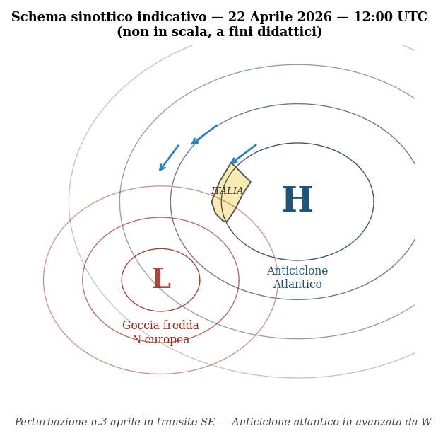

Schema sinottico — perturbazione n.3 aprile 2026 in transito verso SE con anticiclone atlantico in avanzata da W

Nota didattica — Goccia Fredda (Cut-off Low)

Una *cut-off low* si forma quando una saccatura si “stacca” dal flusso zonale principale e diventa un vortice chiuso in quota. A differenza dei fronti classici, evolve lentamente e può rigenerarsi. In questo caso, la goccia fredda di origine scandinava si è isolata tra 500 e 300 hPa, apportando aria con temperatura a 500 hPa di circa −22/−25°C sul Centro-Sud italiano, ben al di sotto della norma stagionale (Ducrocq et al. 2016).

## Analisi della giornata — 22 aprile 2026

### Condizioni attuali e previsione oraria

La giornata del 22 aprile 2026 presenta:

**☀ Ponte del 25 Aprile:** alta pressione salda, sole prevalente e temperature gradevoli 20–24°C su gran parte della Penisola. Anomalia termica positiva di +1/+2°C rispetto alla norma 1991–2020.

### Indicatori termodinamici chiave

Zero termico (mattino)

Precipit. cumulate Roma

3–8

mm previsti

Anomalia termica

+1/+2

°C vs norma 1991–2020

CAPE massimo

~200

J/kg (modesto)

Wind shear 0–6 km

debole

conv. stratiforme

Quota neve

1600

m s.l.m. (in calo)

Con valori di CAPE modesti (~200 J/kg) e wind shear debole nel livello 0–6 km, la convezione rimane **prevalentemente stratiforme** con rovesci isolati. Non si prevede attività temporalesca organizzata né fenomeni estremi (Malguzzi et al. 2006). Il cumulo mensile di aprile 2026 su Roma risulta **nella norma climatologica** (media 1991–2020 ≈ 68 mm, fonte CMN/ISPRA).

## Precipitazioni e profilo termico

### Precipitazioni cumulate previste

FIG. 2 — PRECIPITAZIONI CUMULATE 00:00–24:00 UTC — RANGE ECMWF/GFS

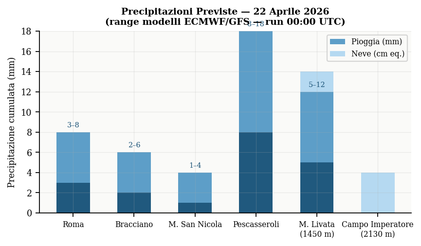

Precipitazioni cumulate previste nelle stazioni di riferimento — 22 aprile 2026

I valori mostrano la distribuzione tipica delle precipitazioni frontali-orografiche sull’Appennino: massimi sul versante adriatico (Pescasseroli 8–18 mm), minimi sulla fascia costiera tirrenica (M. San Nicola 1–4 mm) per effetto del **ridosso appenninico** e della minore distanza dall’alta pressione atlantica (Buzzi e Tibaldi 1978).

### Profilo termico verticale

FIG. 3 — TEMPERATURA VS QUOTA — APPENNINO CENTRALE 12:00 UTC

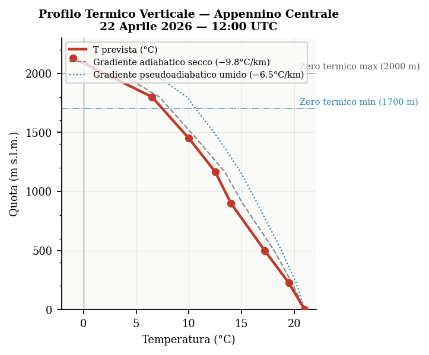

Profilo termico verticale Appennino Centrale con gradiente adiabatico secco e pseudoadiabatico umido — 22 aprile 2026

## Temperature e anomalie climatiche

### Previsione temperature per stazione

| Stazione / Località | Quota | T min | T max | Note |
| --- | --- | --- | --- | --- |
| **Roma** (area metropolitana) | ~20 m | 10–12°C | 20–22°C | UHI +1.5°C su centro |
| **Bracciano** (lago) | ~225 m | 9–11°C | 19–21°C | lake breeze effect |
| **Marina San Nicola** | ~5 m | 10–12°C | 19–21°C | brezza mare pomerid. |
| **Pescasseroli** (PNALM) | ~1167 m | 4–7°C | 12–15°C | cold air pooling |
| **Monte Livata** | ~1450 m | 3–6°C | 10–13°C | pioggia/neve mista |
| **Campo Imperatore** | ~2130 m | −2/−3°C | +2°C | neve 1–4 cm, vento NE |

**Formula del gradiente termico verticale:**

La variazione di temperatura con la quota segue (in prima approssimazione per l’atmosfera reale):

$$\Gamma = -\frac{\partial T}{\partial z} \approx 6.5 \; °C \cdot km^{-1}$$

dove $\Gamma$ è il **lapse rate** ambientale medio (ISA). Valori superiori indicano instabilità atmosferica; valori inferiori indicano inversione termica.

### Anomalia termica vs norma 1991–2020

FIG. 4 — DELTA T°C RISPETTO ALLA NORMA CLIMATICA 1991–2020 (CMN/ISPRA)

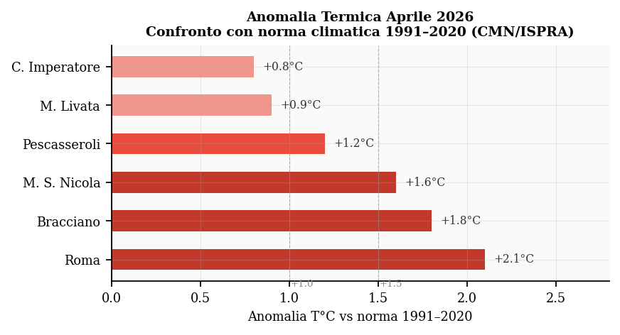

Anomalia termica aprile 2026 rispetto alla norma 1991-2020 per le sei stazioni di riferimento

L’anomalia termica positiva diffusa (+0.8/+2.1°C) è coerente con il **segnale di riscaldamento primaverile precoce** documentato su scala mediterranea da Giorgi e Lionello (2008). Il valore massimo a Roma (+2.1°C) riflette in parte l’**effetto isola di calore urbana** (UHI — *Urban Heat Island*) amplificato nelle giornate con venti deboli.

### Statistica precipitazioni aprile — norma

**Calcolo dell’anomalia standardizzata (Z-score):**

$$Z = \frac{x - \mu}{\sigma}$$

Con $\mu = 68$ mm (norma 1991–2020, Roma) e $\sigma \approx 28$ mm, una stima di 65 mm per aprile 2026 dà:

$$Z = \frac{65 - 68}{28} \approx -0.11$$

Valore **nella norma** (|Z| < 1), nessuna anomalia pluviometrica significativa.

## Climatologia locale — lezioni di meteorologia dei luoghi

### Lago di Bracciano — *Lake Breeze Effect*

Meccanismo didattico

Il Lago di Bracciano (57 km², prof. max ~165 m, quota 164 m s.l.m.) costituisce un **serbatoio termico** con elevatissima inerzia calorica (capacità termica specifica dell’acqua: $c_p = 4.186 \; kJ \cdot kg^{-1} \cdot K^{-1}$, circa 4× quella del suolo). In primavera, la temperatura superficiale del lago (~12–14°C ad aprile) è inferiore alla temperatura della terraferma circostante nelle ore diurne. Questo genera un **gradiente termico orizzontale** terra→lago che induce una circolazione mesoscalare: brezza da terra di notte, brezza da lago di giorno. La brezza lacustre attenua i fenomeni convettivi pomeridiani — spiegando la minor probabilità di rovesci rispetto ai settori meridionali del Lazio nelle giornate di instabilità moderata.

### Monte Livata — meteorologia d’alta quota laziale

Fenomenologia locale

Monte Livata (Subiaco, 1452 m s.l.m.) si trova sul crinale appenninico laziale esposto alle correnti nord-orientali in configurazioni come quella odierna. Il fenomeno dello **stau** (sbarramento orografico) provoca precipitazioni abbondanti sopravvento (versante adriatico) e un **föhn debole** sottovento (versante tirrenico). La quota di transizione pioggia/neve si attesta oggi a ~1500–1700 m, ponendo Livata in una fascia critica. Consiglio agli escursionisti: verificare le condizioni in quota prima di partire.

### Marina San Nicola — brezza di mare tirrenica

Dinamica costiera

Sul litorale laziale settentrionale (Ladispoli, Marina San Nicola), nelle giornate primaverili con pressione variabile prevale l’**effetto termico del Tirreno** (~15–16°C superficie in aprile). La brezza di mare si stabilisce tipicamente tra le 10:00 e le 14:00 locali, apportando aria più fresca e umida dall’ovest. Oggi, con le correnti da NE legate alla perturbazione, questo meccanismo è parzialmente inibito, ma tornerà operativo nei giorni del Ponte del 25 aprile con l’alta pressione.

### Campo Imperatore — osservatorio d’alta quota

Gran Sasso d’Italia — 2130 m s.l.m.

Oggi: accumuli nevosi 1–4 cm, T min −2/−3°C, T max +2°C. Zero termico ~1600–2000 m. Venti 6–30 km/h da NE/ENE. Visibilità buona fuori dalle precipitazioni.

### Pescasseroli — *Cold Air Pooling* in bacino intramontano

Parco Nazionale d’Abruzzo, Lazio e Molise — 1167 m s.l.m.

La conca di Pescasseroli è un esempio paradigmatico di **cold air pooling**: in condizioni di cielo sereno post-perturbazione, l’aria fredda drena per gravità dai versanti circostanti (*drainage flow*) e si accumula nel fondovalle. La **stabilità radiativa notturna** genera inversioni termiche marcate (fino a +10°C di escursione tra fondovalle e crinale). Il meccanismo è descritto dall’equazione del vento drenante:

$$u_d = \sqrt{2g h \frac{\Delta T}{T_0}} \cdot \sin\alpha$$

dove $h$ è lo spessore dello strato freddo, $\Delta T$ il salto termico, $T_0$ la temperatura di riferimento, $\alpha$ l’inclinazione del versante. Questo spiega le minime notturne frequentemente inferiori di 3–6°C rispetto ai versanti circostanti.

## Analisi climatologica e statistica

FIG. 5 — CLIMATOLOGIA APRILE: FREQUENZA TIPI DI TEMPO (LAZIO, 1991–2020) E PLUVIOMETRIA MENSILE ROMA

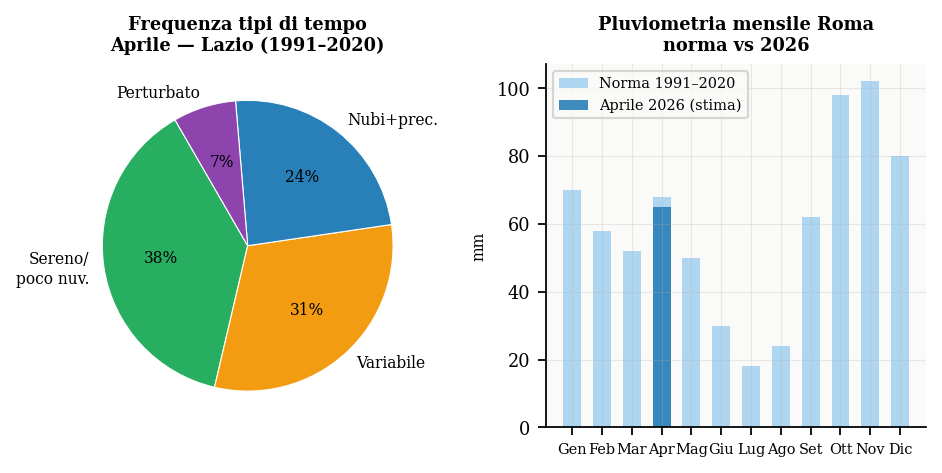

Climatologia aprile Lazio: frequenza tipi di tempo 1991-2020 e pluviometria mensile Roma norma vs aprile 2026

La distribuzione climatologica del mese di aprile sul Lazio (norma 1991–2020) mostra una **frequenza del 31% per giorni variabili** — coerente con la dinamica primaverile mediterranea caratterizzata dall’alternanza tra fasi anticicliche e transiti frontali. Le giornate perturbate (7%) rappresentano gli episodi di instabilità organizzata come quello odierno. Il grafico della pluviometria mensile evidenzia come aprile 2026 si collochi **nella norma climatologica** nonostante la perturbazione in atto (CMN/ISPRA 2023).

## Valutazione rischi e raccomandazioni

| Parametro | Livello | Note |
| --- | --- | --- |
| Allerta idrogeologica | Bassa | Nessun fenomeno estremo previsto |
| Neve in quota (>1600 m) | Moderata | Attenzione a viabilità montana |
| Visibilità in montagna | Ridotta | Nelle fasi di precipitazione |
| Vento (Adriatico/Appennino) | Moderato | Rinforzi locali 30–50 km/h |
| Fulminazione | Assente | CAPE troppo basso per cb organizzati |
| Raccomandazione escursionisti | ⚠ Cautela | Verificare condizioni in quota su Campo Imperatore e Monte Livata |

## Riferimenti bibliografici

Buzzi, A., e S. Tibaldi. 1978. «Cyclogenesis in the lee of the Alps: a case study». *Quarterly Journal of the Royal Meteorological Society* 104 (440): 271–87. https://doi.org/10.1002/qj.49710444012.

CMN/ISPRA. 2023. *Atlante Climatico d’Italia 1991–2020*. Roma: ISPRA. https://www.isprambiente.gov.it.

Ducrocq, V. et al. 2016. «HyMeX-SOP1, the field campaign dedicated to heavy precipitation and flash flooding in the northwestern Mediterranean». *Bulletin of the American Meteorological Society* 97 (7): 1083–1101. https://doi.org/10.1175/BAMS-D-14-00083.1.

Giorgi, F., e P. Lionello. 2008. «Climate change projections for the Mediterranean region». *Global and Planetary Change* 63 (2–3): 90–104. https://doi.org/10.1016/j.gloplacha.2007.09.005.

Malguzzi, P. et al. 2006. «The 1966 "century" flood in Italy: a meteorological and hydrological revisitation». *Journal of Geophysical Research: Atmospheres* 111 (D24). https://doi.org/10.1029/2006JD007111.

FONTI DATI: Output modelli ECMWF IFS CY48R1 e GFS NCEP — run 00:00 UTC 22 aprile 2026. Dati climatologici norma 1991–2020: CMN/ISPRA (Atlante Climatico d’Italia 2023). Bollettini regionali: DPC, AllarMeteo Abruzzo, newtuscia.it, ilmeteo.it. I valori di previsione sono indicativi e soggetti ad aggiornamento con i successivi run modellistici. Per allerte ufficiali consultare sempre DPC e protezione civile regionale. Questo documento ha esclusivamente finalità scientifiche e didattiche. PRODOTTO: 22 APR 2026 09:00 UTC — VALIDITÀ: 22 APR 2026 00:00–24:00 UTC